# Ex3_BeatrizAlmeida

Importando os dados do dataset escolhido e atribuíndo à variável cars.

```r
cars <- read.csv('/home/beatriz-pessoal/Documents/UTFPR/CDA/Estatística e R/Ex3_BeatrizAlmeida/cars.csv')
```

## Introdução

O objetivo da presente análise é, através dos dados de uma seleção variada de carros usados e seus preços de revenda, ajustar um modelo de regressão linear múltipla que poderá prever os possíveis preços para outros automóveis a partir de suas características. Um modelo como esse pode auxiliar compradores e vendedores a precificarem carros de acordo com os valores do mercado.

## Contextualização e preparação do conjunto de dados

O conjunto de dados escolhido contém informações a respeito de carros usados de variadas marcas e modelos. A seguir observa-se as primeiras linhas do dataset.

```r
head(cars)
```

```
##   Car_ID   Brand   Model Year Kilometers_Driven Fuel_Type Transmission
## 1      1  Toyota Corolla 2018             50000    Petrol       Manual
## 2      2   Honda   Civic 2019             40000    Petrol    Automatic
## 3      3    Ford Mustang 2017             20000    Petrol    Automatic
## 4      4  Maruti   Swift 2020             30000    Diesel       Manual
## 5      5 Hyundai  Sonata 2016             60000    Diesel    Automatic
## 6      6    Tata   Nexon 2019             35000    Petrol       Manual
##   Owner_Type Mileage Engine Power Seats   Price
## 1      First      15   1498   108     5  800000
## 2     Second      17   1597   140     5 1000000
## 3      First      10   4951   395     4 2500000
## 4      Third      23   1248    74     5  600000
## 5     Second      18   1999   194     5  850000
## 6      First      17   1198   108     5  750000
```

Com ajuda da função dim podemos observar a quantidade de observações e variáveis, respectivamente:

```r
dim(cars)
```

```
## [1] 100  13
```

(100 observações e 13 variáveis)

### Preparação dos dados

Com intuito de facilitar a análise e também a compreensão dos dados, será feita a conversão dos valores de *Price*, que estão representados pela moeda indiana (INR), para a moeda brasileira (BRL). Para este cálculo está sendo considerada a taxa de conversão válida para o momento em que a análise esta sendo realizada, a qual é igual a 0.0646.

```r
require(dplyr)

current_exchange_rate = 0.0646

cars <- cars %>%
  dplyr::mutate(Price_BRL = Price * current_exchange_rate)
```

Inicialmente será verificada a possibilidade de um modelo com uso das covariáveis *Kilometers_Driven*, *Mileage*, *Power*, *Engine*, *Owner_Type*, *Transmission* e *Fuel_Type*. A variável resposta será *Price_BRL*, ou seja, será o valor que o modelo tentará prever.

Selecionando apenas as variáveis de interesse supracitadas. A variáveis qualitativas serão transformadas em factors para possibilitar a modelagem.

```r
cars_filt <- cars %>%
  dplyr::select(Price_BRL, Kilometers_Driven, Mileage, Power, Engine, Owner_Type, Transmission, Fuel_Type) %>%
  dplyr::mutate(Owner_Type_factor = factor(Owner_Type, levels = c('First', 'Second', 'Third'))) %>%
  dplyr::mutate(Transmission_factor = factor(Transmission, levels = c('Manual', 'Automatic'))) %>%
  dplyr::mutate(Fuel_Type_factor = factor(Fuel_Type, levels = c('Petrol', 'Diesel')))


head(cars_filt)
```

```
##   Price_BRL Kilometers_Driven Mileage Power Engine Owner_Type Transmission
## 1     51680             50000      15   108   1498      First       Manual
## 2     64600             40000      17   140   1597     Second    Automatic
## 3    161500             20000      10   395   4951      First    Automatic
## 4     38760             30000      23    74   1248      Third       Manual
## 5     54910             60000      18   194   1999     Second    Automatic
## 6     48450             35000      17   108   1198      First       Manual
##   Fuel_Type Owner_Type_factor Transmission_factor Fuel_Type_factor
## 1    Petrol             First              Manual           Petrol
## 2    Petrol            Second           Automatic           Petrol
## 3    Petrol             First           Automatic           Petrol
## 4    Diesel             Third              Manual           Diesel
## 5    Diesel            Second           Automatic           Diesel
## 6    Petrol             First              Manual           Petrol
```

### Contextualização dos dados

Entendendo a estrutura dos dados:

```r
str(cars_filt)
```

```
## 'data.frame':    100 obs. of  11 variables:
##  $ Price_BRL          : num  51680 64600 161500 38760 54910 ...
##  $ Kilometers_Driven  : int  50000 40000 20000 30000 60000 35000 45000 25000 30000 20000 ...
##  $ Mileage            : int  15 17 10 23 18 17 15 18 18 20 ...
##  $ Power              : int  108 140 395 74 194 108 140 76 187 190 ...
##  $ Engine             : int  1498 1597 4951 1248 1999 1198 2179 999 1968 1995 ...
##  $ Owner_Type         : chr  "First" "Second" "First" "Third" ...
##  $ Transmission       : chr  "Manual" "Automatic" "Automatic" "Manual" ...
##  $ Fuel_Type          : chr  "Petrol" "Petrol" "Petrol" "Diesel" ...
##  $ Owner_Type_factor  : Factor w/ 3 levels "First","Second",..: 1 2 1 3 2 1 2 1 1 2 ...
##  $ Transmission_factor: Factor w/ 2 levels "Manual","Automatic": 1 2 2 1 2 1 2 2 2 2 ...
##  $ Fuel_Type_factor   : Factor w/ 2 levels "Petrol","Diesel": 1 1 1 2 2 1 2 1 2 2 ...
```

Conforme indicado acima, após os ajustes realizados, o dataset continua com suas 100 observações e agora conta com 5 variáveis quantitativas, as quais estão adequadamente classificadas entre int e num. As variáveis qualitativas são 6 e dessas, 3 são chr as outras 3 se tratam das mesmas chr transformadas em Factor.

#### Descrição das colunas

- **Price_BRL** $\Rightarrow$ O preço máximo em BRL, moeda brasileira.
- **Kilometers_Driven** $\Rightarrow$ Total de kilômetros rodados pelo carro.-
- **Mileage** $\Rightarrow$ Kilômetros que o carro faz por litro de combustível, ou seja, sua eficiência.
- **Power** $\Rightarrow$ Potência máxima do carro em bhp (Brake Horsepower).
- **Engine** $\Rightarrow$ Capacidade do motor em cm³ (centímetros cúbicos).
- **Owner_Type** $\Rightarrow$ Indica o número de proprietários anteriores do carro (ex.: First = Primeiro, Second = Segundo, Third = Terceiro).
- **Transmission** $\Rightarrow$ Tipo de transmissão do carro (ex.: Manual, Automatic)
- **Fuel_Type** $\Rightarrow$ O tipo de combustível utilizado pelo carro (ex.: Petrol, Diesel).

Para aprofundar a análise desses dados, observa-se algumas estatísticas descritivas.

```r
summary(cars_filt)
```

```
##    Price_BRL      Kilometers_Driven    Mileage          Power
##  Min.   : 29070   Min.   :10000     Min.   :10.00   Min.   : 68.0
##  1st Qu.: 45220   1st Qu.:22000     1st Qu.:15.00   1st Qu.:103.0
##  Median : 83980   Median :27000     Median :17.00   Median :148.0
##  Mean   :101680   Mean   :28150     Mean   :17.21   Mean   :158.1
##  3rd Qu.:161500   3rd Qu.:32000     3rd Qu.:19.00   3rd Qu.:187.0
##  Max.   :258400   Max.   :60000     Max.   :25.00   Max.   :396.0
##      Engine      Owner_Type        Transmission        Fuel_Type
##  Min.   : 999   Length:100         Length:100         Length:100
##  1st Qu.:1462   Class :character   Class :character   Class :character
##  Median :1774   Mode  :character   Mode  :character   Mode  :character
##  Mean   :1855
##  3rd Qu.:2143
##  Max.   :4951
##  Owner_Type_factor Transmission_factor Fuel_Type_factor
##  First :44         Manual   :43        Petrol:52
##  Second:43         Automatic:57        Diesel:48
##  Third :13
##
##
##
```

Com relação ao preço, observa-se que há uma grande diferença entre o valor mínimo (R$ 29.070,00) e o valor máximo (R$ 258.400,00). Verificaremos melhor esses valores através de um box plot.

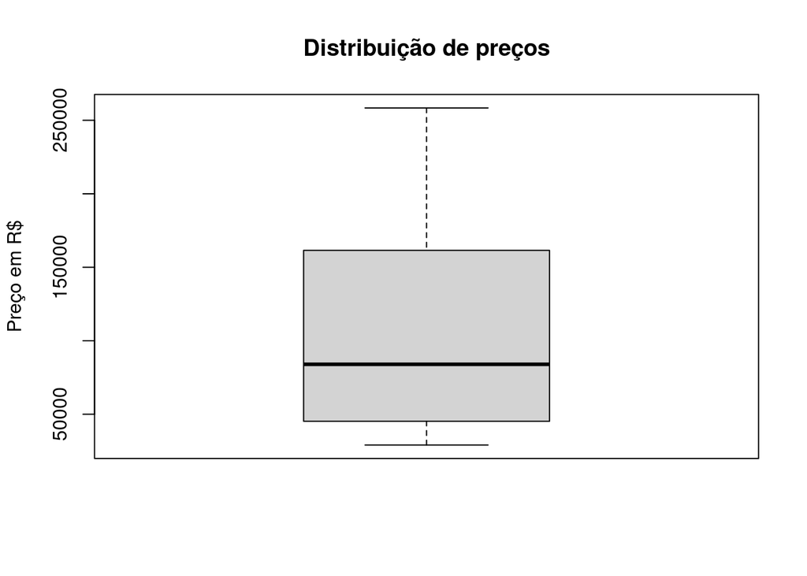

```r
boxplot(
    cars_filt$Price_BRL,
    main='Distribuição de preços',
    ylab='Preço em R$'
)
```

Agora olhando para as variáveis Kilometers_Driven e Power, observa-se o seguinte:

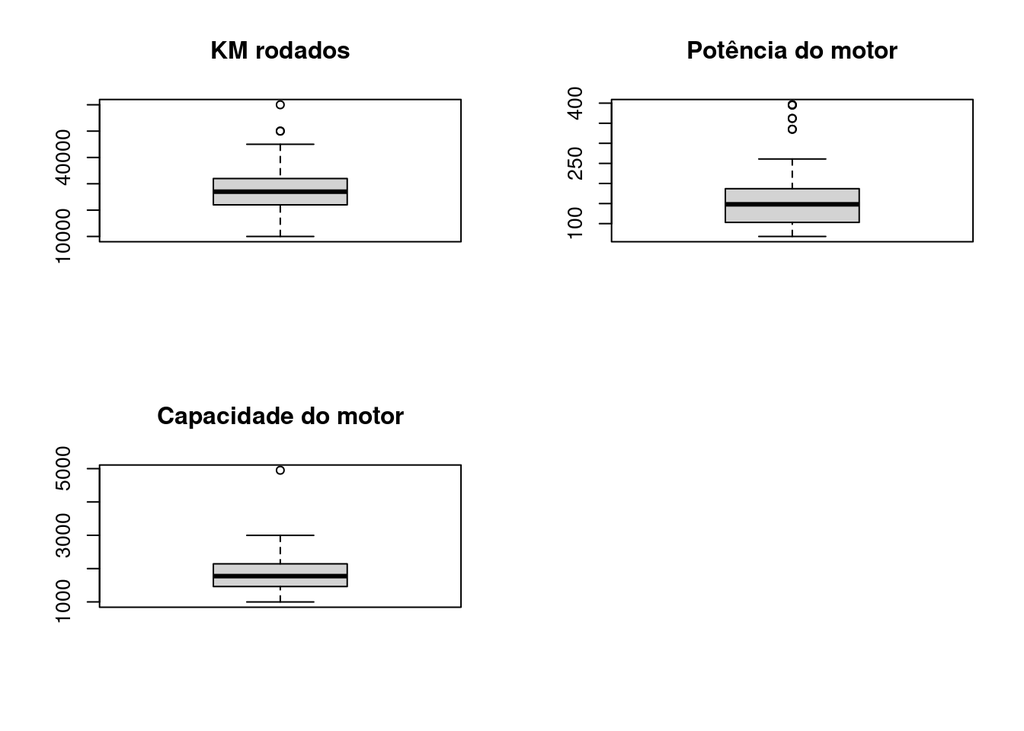

```r
par(mfrow = c(2, 2))
boxplot(cars_filt$Kilometers_Driven, main='KM rodados')
boxplot(cars_filt$Power, main='Potência do motor')
boxplot(cars_filt$Engine, main='Capacidade do motor')
```

Há uma distribuição equilibrada para os KMs rodados dos carros da amostra. Para ambas as variáveis existem alguns outliers.

## Modelagem

### Relação linear

Verificando se as relações entre as variáveis X com a Y são lineares.

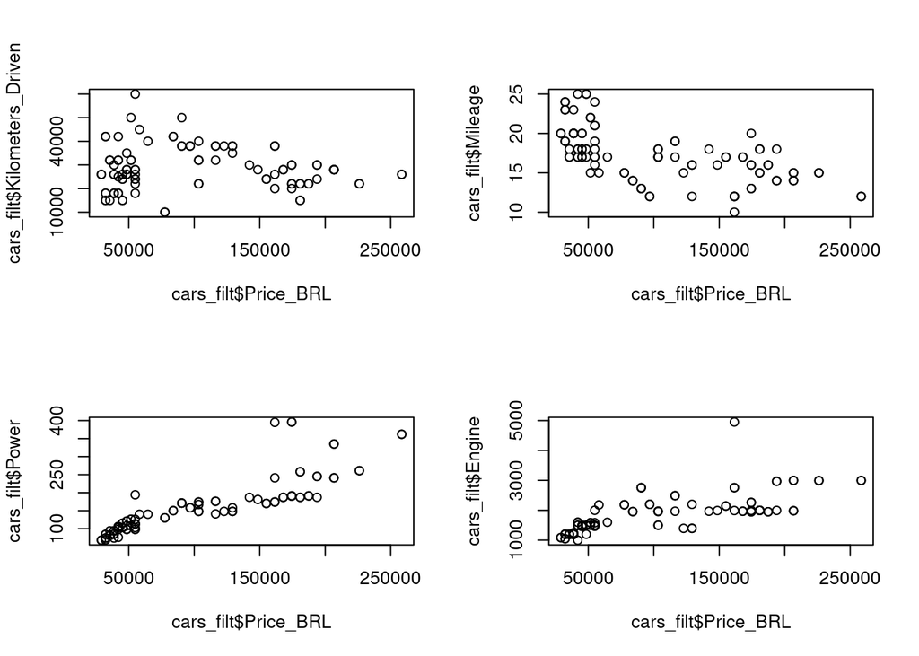

```r
par(mfrow = c(2, 2))
plot(cars_filt$Price_BRL, cars_filt$Kilometers_Driven)
plot(cars_filt$Price_BRL, cars_filt$Mileage)
plot(cars_filt$Price_BRL, cars_filt$Power)
plot(cars_filt$Price_BRL, cars_filt$Engine)
```

### Multicolinearidade

Verificando se há multicolinearidade entre as variáveis X que são do tipo quantitativa, ou seja, se elas tem uma correlação forte, maior do que 0.8.

```r
cars_quant <- cars %>%
  dplyr::select(Price_BRL, Kilometers_Driven, Mileage, Power, Engine)

cor(cars_quant)
```

```
##                     Price_BRL Kilometers_Driven    Mileage       Power
## Price_BRL          1.00000000       -0.05110405 -0.5952520  0.85661983
## Kilometers_Driven -0.05110405        1.00000000 -0.1044366 -0.02673176
## Mileage           -0.59525201       -0.10443657  1.0000000 -0.64889438
## Power              0.85661983       -0.02673176 -0.6488944  1.00000000
## Engine             0.71446479        0.11234045 -0.6809491  0.80570882
##                       Engine
## Price_BRL          0.7144648
## Kilometers_Driven  0.1123405
## Mileage           -0.6809491
## Power              0.8057088
## Engine             1.0000000
```

As covariáveis Engine e Power tem uma correlação de 0.805, um pouco acima do desejado. Considerando que, entre as duas, Power tem maior correlação com Price_BRL, a covariável Engine será retirada da modelagem. A partir da observação das correlações também conclui-se que a covariável Kilometers_Driven (Kilômetros rodados) neste dataset não tem forte correlação com o preço. Mesmo que em um cenário real isso pareça não fazer sentido, é necessário desconsiderar essa variável para que não enviese os resultados do modelo.

### Ajuste do modelo

A seguir são realizadas três tentativas de ajuste do modelo para validar qual delas apresenta melhor resultado.

- O Modelo 1 inclui todas as variáveis qualitativas e as quantitativas que foram selecionada após as observações da sessão de Multicolinearidade.
- O Modelo 2 inclui apenas as variáveis quantitativas.
- O Modelo 3 tem as mesmas variáveis do 1, mas inclui a Engine que foi retirada devido a Multicolinearidade.

```r
modelo1_rlm <- stats::lm(Price_BRL ~ Mileage + Power + Owner_Type_factor + Transmission_factor + Fuel_Type_factor, data = cars_filt)
summary(modelo1_rlm) # 0.8138
```

```
##
## Call:
## stats::lm(formula = Price_BRL ~ Mileage + Power + Owner_Type_factor +
##     Transmission_factor + Fuel_Type_factor, data = cars_filt)
##
## Residuals:
##    Min     1Q Median     3Q    Max
## -92504  -9529   5136  13244  46805
##
## Coefficients:
##                               Estimate Std. Error t value Pr(>|t|)
## (Intercept)                   37535.88   26160.80   1.435  0.15469
## Mileage                       -2364.67    1126.82  -2.099  0.03857 *
## Power                           509.93      57.16   8.921 3.92e-14 ***
## Owner_Type_factorSecond      -14025.30    6279.53  -2.233  0.02791 *
## Owner_Type_factorThird        -7512.08    9977.18  -0.753  0.45340
## Transmission_factorAutomatic  38691.10    7222.20   5.357 6.09e-07 ***
## Fuel_Type_factorDiesel        19079.73    5993.08   3.184  0.00198 **
## ---
## Signif. codes:  0 '***' 0.001 '**' 0.01 '*' 0.05 '.' 0.1 ' ' 1
##
## Residual standard error: 27880 on 93 degrees of freedom
## Multiple R-squared:  0.8251, Adjusted R-squared:  0.8138
## F-statistic: 73.12 on 6 and 93 DF,  p-value: < 2.2e-16
```

```r
modelo2_rlm <- stats::lm(Price_BRL ~ Mileage + Power, data = cars_filt)
summary(modelo2_rlm) # 0.731
```

```
##
## Call:
## stats::lm(formula = Price_BRL ~ Mileage + Power, data = cars_filt)
##
## Residuals:
##     Min      1Q  Median      3Q     Max
## -111325  -18841   -8118   22606   73477
##
## Coefficients:
##             Estimate Std. Error t value Pr(>|t|)
## (Intercept) 16685.11   29921.17   0.558    0.578
## Mileage     -1328.48    1337.33  -0.993    0.323
## Power         682.09      57.51  11.860   <2e-16 ***
## ---
## Signif. codes:  0 '***' 0.001 '**' 0.01 '*' 0.05 '.' 0.1 ' ' 1
##
## Residual standard error: 33510 on 97 degrees of freedom
## Multiple R-squared:  0.7365, Adjusted R-squared:  0.731
## F-statistic: 135.5 on 2 and 97 DF,  p-value: < 2.2e-16
```

```r
modelo3_rlm <- stats::lm(Price_BRL ~ Mileage + Power + Engine + Owner_Type_factor + Transmission_factor + Fuel_Type_factor, data = cars_filt)
summary(modelo3_rlm) # 0.8134
```

```
##
## Call:
## stats::lm(formula = Price_BRL ~ Mileage + Power + Engine + Owner_Type_factor +
##     Transmission_factor + Fuel_Type_factor, data = cars_filt)
##
## Residuals:
##    Min     1Q Median     3Q    Max
## -84167  -9362   5056  16005  45650
##
## Coefficients:
##                                Estimate Std. Error t value Pr(>|t|)
## (Intercept)                   52930.766  31317.749   1.690  0.09439 .
## Mileage                       -2830.252   1241.853  -2.279  0.02498 *
## Power                           554.379     75.717   7.322 9.03e-11 ***
## Engine                           -8.323      9.285  -0.896  0.37239
## Owner_Type_factorSecond      -13524.640   6310.939  -2.143  0.03475 *
## Owner_Type_factorThird        -7742.863   9991.059  -0.775  0.44034
## Transmission_factorAutomatic  37772.014   7302.183   5.173 1.34e-06 ***
## Fuel_Type_factorDiesel        21931.427   6790.732   3.230  0.00172 **
## ---
## Signif. codes:  0 '***' 0.001 '**' 0.01 '*' 0.05 '.' 0.1 ' ' 1
##
## Residual standard error: 27910 on 92 degrees of freedom
## Multiple R-squared:  0.8266, Adjusted R-squared:  0.8134
## F-statistic: 62.66 on 7 and 92 DF,  p-value: < 2.2e-16
```

### Avaliação do ajuste

Ao olhar para o R² dos três modelos, conclui-se em um primeiro momento que o Modelo 1 é o mais adequado, com R² = 0.8138.

Através da teoria do AIC pode-se ter mais uma comprovação do modelo de melhor ajuste. Quanto menor o valor do AIC, melhor o ajuste.

```r
stats::AIC(modelo1_rlm)
```

```
## [1] 2339.674
```

```r
stats::AIC(modelo2_rlm)
```

```
## [1] 2372.668
```

```r
stats::AIC(modelo3_rlm)
```

```
## [1] 2340.804
```

O menor valor de AIC é de 2339.674, correspondente também ao Modelo 1.

Considerando os testes realizados, segue-se com o Modelo 1 para avaliação do ajuste.

#### Resíduos

Através dos gráficos é possível observar que há uma certa Homocedasticidade nos resíduos de cada covariável. Mas vamos verificar com relação a normalidade para entender se é possível melhorar o ajuste.

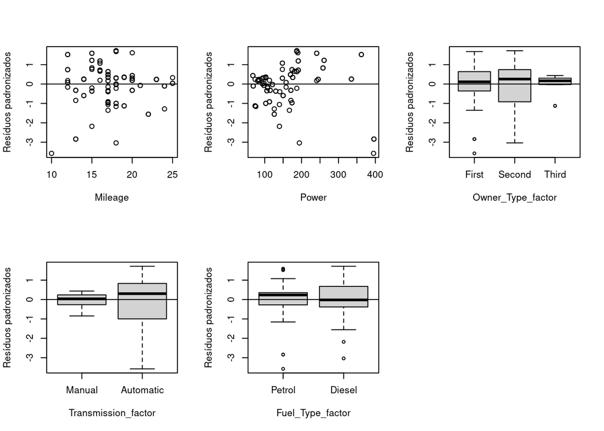

```r
par(mfrow = c(2,3))
plot(x = cars_filt$Mileage , y = stats::rstandard(modelo1_rlm),
     xlab = "Mileage", ylab = "Resíduos padronizados")
abline(0, 0)


plot(x = cars_filt$Power , y = stats::rstandard(modelo1_rlm),
     xlab = "Power", ylab = "Resíduos padronizados")
abline(0, 0)

plot(x = cars_filt$Owner_Type_factor , y = stats::rstandard(modelo1_rlm),
     xlab = "Owner_Type_factor", ylab = "Resíduos padronizados")
abline(0, 0)

plot(x = cars_filt$Transmission_factor , y = stats::rstandard(modelo1_rlm),
     xlab = "Transmission_factor", ylab = "Resíduos padronizados")
abline(0, 0)

plot(x = cars_filt$Fuel_Type_factor , y = stats::rstandard(modelo1_rlm),
     xlab = "Fuel_Type_factor", ylab = "Resíduos padronizados")
abline(0, 0)
```

#### Normalidade dos resíduos

O QQPlot abaixo demonstra uma não normalidade dos resíduos.

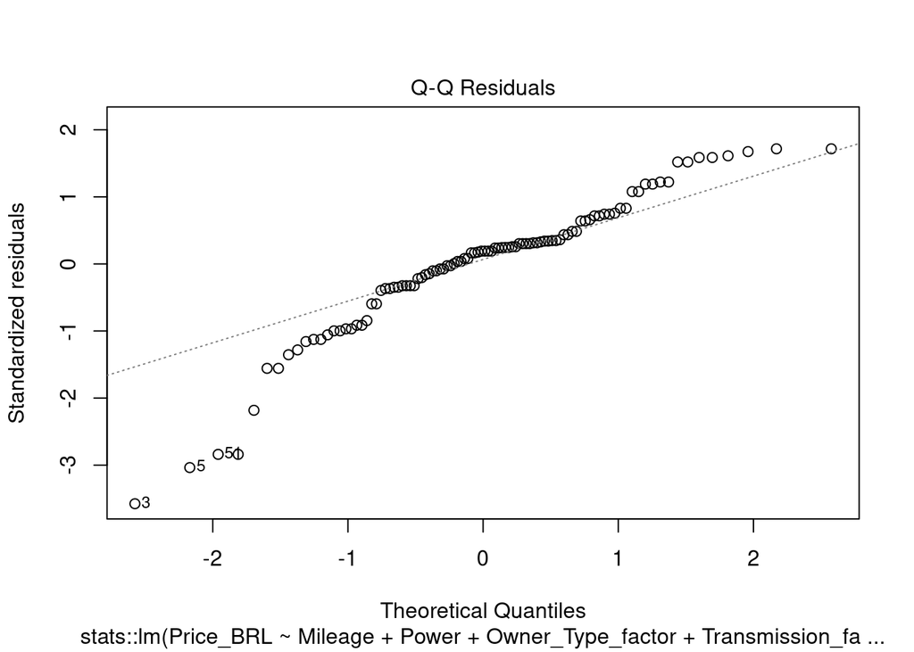

```r
plot(modelo1_rlm, which = 2)
```

#### Distância de Cook

O gráfico de distância de Cook também demonstra que há alguns pontos atípicos que podem estar interferindo no modelo.

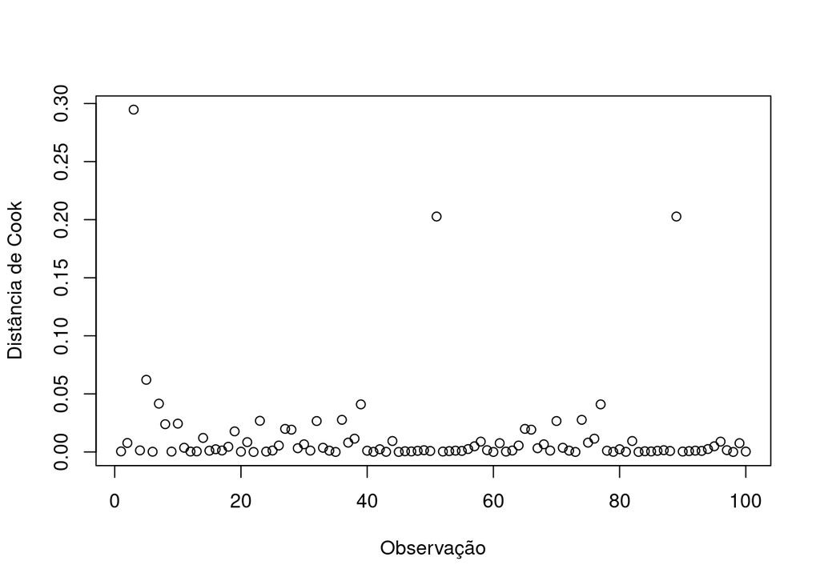

```r
plot(cooks.distance(modelo1_rlm),
          xlab = "Observação",
          ylab = "Distância de Cook")
```

Para corrigir a normalidade e a distância de cook, serão removidos os pontos de influência observados.

Abaixo é armazenada a distância de cook em uma variável ‘cook_dist’, definido o limite de 4/n e através da função ‘which’ armazenadas as observações infulentes na variável ‘obs_influentes’. Após isso são removidas essas observações do dataset e o modelo é novamente ajustado e salvo como ‘modelo4_rlm’. Após isso, o R² passa a ter um valor melhor de 0.9085.

```r
cook_dist <- cooks.distance(modelo1_rlm)

n <- nrow(cars_filt)
limite <- 4 / n

obs_influentes <- which(cook_dist > limite)

cars_filt_sem_influentes <- cars_filt[-obs_influentes, ]

modelo4_rlm <- stats::lm(Price_BRL ~ Mileage + Power + Owner_Type_factor + Transmission_factor + Fuel_Type_factor, data = cars_filt_sem_influentes)
summary(modelo4_rlm)
```

```
##
## Call:
## stats::lm(formula = Price_BRL ~ Mileage + Power + Owner_Type_factor +
##     Transmission_factor + Fuel_Type_factor, data = cars_filt_sem_influentes)
##
## Residuals:
##    Min     1Q Median     3Q    Max
## -41169 -10852   2692   8988  42606
##
## Coefficients:
##                               Estimate Std. Error t value Pr(>|t|)
## (Intercept)                   -2620.82   18672.75  -0.140  0.88871
## Mileage                       -1370.31     774.51  -1.769  0.08040 .
## Power                           743.00      52.48  14.158  < 2e-16 ***
## Owner_Type_factorSecond      -19745.61    4350.06  -4.539 1.82e-05 ***
## Owner_Type_factorThird        -5485.54    6660.41  -0.824  0.41244
## Transmission_factorAutomatic  32515.54    5033.59   6.460 6.02e-09 ***
## Fuel_Type_factorDiesel        13849.46    4211.34   3.289  0.00146 **
## ---
## Signif. codes:  0 '***' 0.001 '**' 0.01 '*' 0.05 '.' 0.1 ' ' 1
##
## Residual standard error: 18500 on 86 degrees of freedom
## Multiple R-squared:  0.9144, Adjusted R-squared:  0.9085
## F-statistic: 153.2 on 6 and 86 DF,  p-value: < 2.2e-16
```

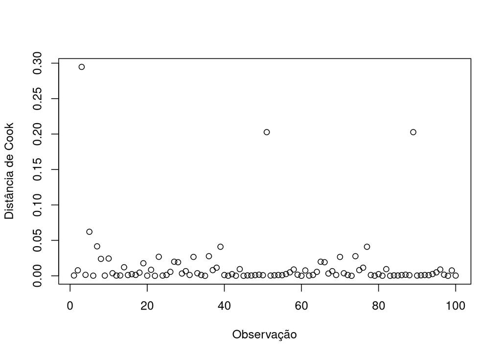

```r
plot(cooks.distance(modelo1_rlm),
          xlab = "Observação",
          ylab = "Distância de Cook")
```

Agora observam-se nos gráficos uma normalidade de resíduos.

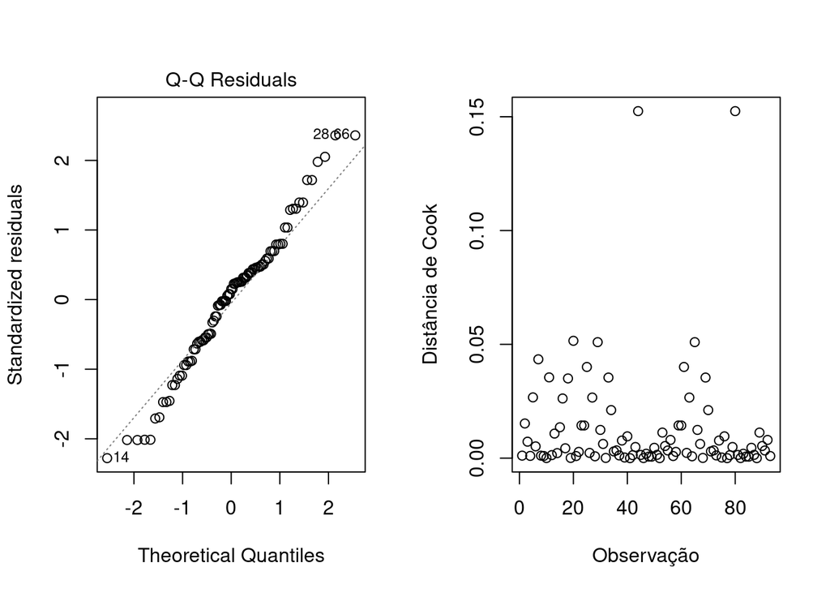

```r
par(mfrow = c(1,2))

plot(modelo4_rlm, which = 2)
plot(cooks.distance(modelo4_rlm),
          xlab = "Observação",
          ylab = "Distância de Cook")
```

Agora há uma melhora também na Homocedasticidade dos rasíduos.

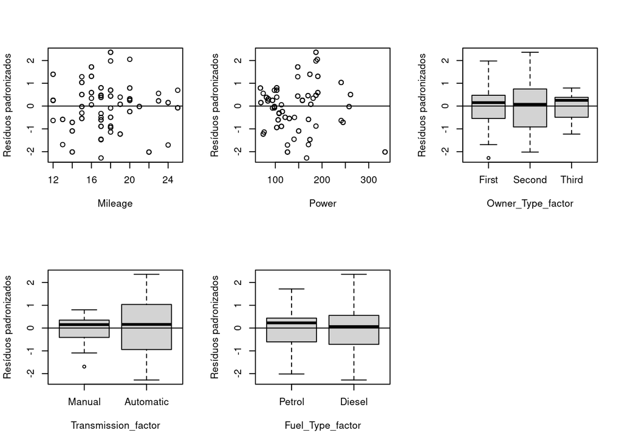

```r
par(mfrow = c(2,3))
plot(x = cars_filt_sem_influentes$Mileage , y = stats::rstandard(modelo4_rlm),
     xlab = "Mileage", ylab = "Resíduos padronizados")
abline(0, 0)

plot(x = cars_filt_sem_influentes$Power , y = stats::rstandard(modelo4_rlm),
     xlab = "Power", ylab = "Resíduos padronizados")
abline(0, 0)

plot(x = cars_filt_sem_influentes$Owner_Type_factor , y = stats::rstandard(modelo4_rlm),
     xlab = "Owner_Type_factor", ylab = "Resíduos padronizados")
abline(0, 0)

plot(x = cars_filt_sem_influentes$Transmission_factor , y = stats::rstandard(modelo4_rlm),
     xlab = "Transmission_factor", ylab = "Resíduos padronizados")
abline(0, 0)

plot(x = cars_filt_sem_influentes$Fuel_Type_factor , y = stats::rstandard(modelo4_rlm),
     xlab = "Fuel_Type_factor", ylab = "Resíduos padronizados")
abline(0, 0)
```

Por fim pode-se comprovar o ajuste do modelo através da checagem que faz a ferramenta performance.

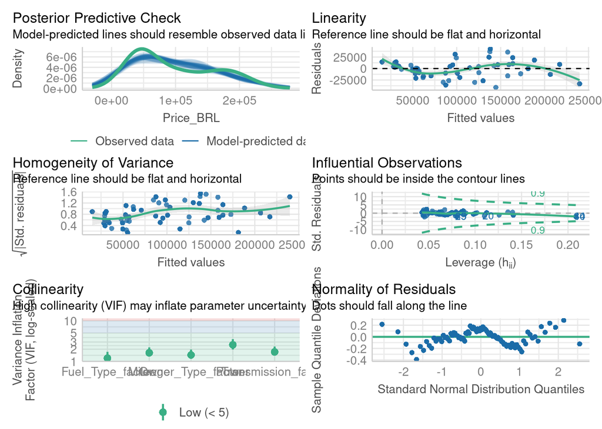

```r
require(performance)
require(see)

performance::check_model(modelo4_rlm)
```

- O 1º gráfico demonstra que a distribuição entre os valores previstos e observados está aceitável, seguindo uma caricatura muito semelhante.
- O 2º gráfico avalia a linearidade das variáveis dependentes e independentes, que se encontra também aceitável.
- O 3º gráfico aponta que os resíduos se distribuem de maneira homogênea.
- O 4ª gráfico da distâncida de cook demonstra que nenhuma observação está fora dos limites marcados, ou seja, não há nenhum ponto de alavanca que possa prejudicar as estimativas.
- O 5ª gráfico demonstra a Multicolinearidade das variáveis, conforme já havia sido verificado anteriormente, o gráfico comprova que não.
- O 6º gráfico demosntra normalidade dos resíduos.

### Interpretação dos resultados

A seguir a interpretação dos resultados obtidos com o modelo ajustado.

```r
summary(modelo4_rlm)
```

```
##
## Call:
## stats::lm(formula = Price_BRL ~ Mileage + Power + Owner_Type_factor +
##     Transmission_factor + Fuel_Type_factor, data = cars_filt_sem_influentes)
##
## Residuals:
##    Min     1Q Median     3Q    Max
## -41169 -10852   2692   8988  42606
##
## Coefficients:
##                               Estimate Std. Error t value Pr(>|t|)
## (Intercept)                   -2620.82   18672.75  -0.140  0.88871
## Mileage                       -1370.31     774.51  -1.769  0.08040 .
## Power                           743.00      52.48  14.158  < 2e-16 ***
## Owner_Type_factorSecond      -19745.61    4350.06  -4.539 1.82e-05 ***
## Owner_Type_factorThird        -5485.54    6660.41  -0.824  0.41244
## Transmission_factorAutomatic  32515.54    5033.59   6.460 6.02e-09 ***
## Fuel_Type_factorDiesel        13849.46    4211.34   3.289  0.00146 **
## ---
## Signif. codes:  0 '***' 0.001 '**' 0.01 '*' 0.05 '.' 0.1 ' ' 1
##
## Residual standard error: 18500 on 86 degrees of freedom
## Multiple R-squared:  0.9144, Adjusted R-squared:  0.9085
## F-statistic: 153.2 on 6 and 86 DF,  p-value: < 2.2e-16
```

- **R²** - O R² indica que 90,85% da variabilidade do preço dos carros é explicada pelas covariáveis utilizadas no modelo: Eficiência, Potência, Tipo de dono (Primeira mão, segunda mão, etc), Tipo de transmissão e Tipo de combustível.
- **Beta1 Mileage** - Para o aumento de 1km de Eficiência, há uma diminuição de R$ 1.370,31 no valor do carro.
- **Beta2 Power** - Para o aumento de 1 cavalo de potência do carro, há um aumento de R$ 743,00 no valor do mesmo.
- **Beta3 Owner_Type_factorSecond** - Há uma diminuição de R$ 19.745,61 no valor de um carro de segunda mão com relação a um de primeira mão.
- **Beta4 Owner_Type_factorThird** - Há uma diminuição de R$ 5.485,54 no valor de um carro de terceira mão com relação a um de primeira mão.
- **Beta5 Transmission_factorAutomatic** - Há um aumento de R$ 32.515,54 no valor de um carro de Transmissão Automatica em relação a um Manual.
- **Beta6 Fuel_Type_factorDiesel** - Há um aumento de R$ 13.849,46 no valor de um carro de combustível de Diesel em relação a um carro que de combustível de Petróleo.